# No Name LR Model

Matt Dunning

August 14, 2018

Packages Used

```r
##ml library
#install.packages("caret)
library(caret)
##data transformation
#install.packages("dplyr")
library(dplyr)
##stats package for regression objects
#install.packages("stats")
library(stats)
##hypothesis/ chi-sq testing
#install.packages("car")
library(car)
#logistic regression eval - ROC curve
#install.packages("pROC")
library(pROC)
library(Hmisc)
library(ggplot2)
```

Read in data

```r
##Read in March Data,  Source = MW0 in this file
df_input_rmd <- read.csv("C:/Users/mdunning/Documents/Data/No_Name_Analysis_Data/march_name_analysis_2/model/march_name_analysis_2.csv")
#(nrows = 448986)
#head(df_input_rmd)
```

Filter out records with name and clubs close to sams cub

```r
##Filter out records with names and records in clubs close to sams --- (nrows=158027)
df_temp_rmd <- df_input_rmd %>% filter(noname == 1,!BJsClub1 %in% c(038,
                                             045,
                                             048,
                                             061,
                                             062,
                                             067,
                                             093,
                                             123,
                                             129,
                                             139,
                                             141,
                                             150,
                                             168,
                                             180,
                                             184,
                                             185,
                                             189,
                                             211,
                                             318,
                                             370
                  ))

#head(df_temp_rmd)

##Responses for entire population
table(df_temp_rmd$resp_flag)
```

```
##
##      0      1
## 157625    402
```

Subset significant features

```r
##Subset Dataset selecting features determined most significant by Stepwise Chi-Squared tests
df_train <- subset(df_temp_rmd, select = c("resp_flag",
                                        "X3yr_RR",
                                        "comp_distance_flag",
                                        "Past_Pds"
))

df_test <- subset(df_temp_rmd, select = c("resp_flag",
                                      "X3yr_RR",
                                      "comp_distance_flag",
                                      "Past_Pds"
))
```

```r
##Decribe Data reporting descriptive stats on fetures
describe(df_train)
```

```
## df_train
##
##  4  Variables      158027  Observations
## ---------------------------------------------------------------------------
## resp_flag
##        n  missing distinct     Info      Sum     Mean      Gmd
##   158027        0        2    0.008      402 0.002544 0.005075
##
## ---------------------------------------------------------------------------
## X3yr_RR
##        n  missing distinct     Info     Mean      Gmd      .05      .10
##   158027        0     1351        1    15.95    6.994    7.750    8.842
##      .25      .50      .75      .90      .95
##   10.944   15.110   19.902   24.632   27.353
##
## lowest :   0.0000   1.7544   1.8182   1.9231   2.3256
## highest:  66.6667  73.5294  75.0000 100.0000 200.0000
## ---------------------------------------------------------------------------
## comp_distance_flag
##        n  missing distinct     Info      Sum     Mean      Gmd
##   158027        0        2    0.637   109730   0.6944   0.4244
##
## ---------------------------------------------------------------------------
## Past_Pds
##        n  missing distinct     Info     Mean      Gmd      .05      .10
##   158027        0      167        1    70.52    43.41       20       29
##      .25      .50      .75      .90      .95
##       43       63       88      119      160
##
## lowest :   0   1   2   3   4, highest: 223 229 230 244 260
## ---------------------------------------------------------------------------
```

```r
describe(df_test)
```

```
## df_test
##
##  4  Variables      158027  Observations
## ---------------------------------------------------------------------------
## resp_flag
##        n  missing distinct     Info      Sum     Mean      Gmd
##   158027        0        2    0.008      402 0.002544 0.005075
##
## ---------------------------------------------------------------------------
## X3yr_RR
##        n  missing distinct     Info     Mean      Gmd      .05      .10
##   158027        0     1351        1    15.95    6.994    7.750    8.842
##      .25      .50      .75      .90      .95
##   10.944   15.110   19.902   24.632   27.353
##
## lowest :   0.0000   1.7544   1.8182   1.9231   2.3256
## highest:  66.6667  73.5294  75.0000 100.0000 200.0000
## ---------------------------------------------------------------------------
## comp_distance_flag
##        n  missing distinct     Info      Sum     Mean      Gmd
##   158027        0        2    0.637   109730   0.6944   0.4244
##
## ---------------------------------------------------------------------------
## Past_Pds
##        n  missing distinct     Info     Mean      Gmd      .05      .10
##   158027        0      167        1    70.52    43.41       20       29
##      .25      .50      .75      .90      .95
##       43       63       88      119      160
##
## lowest :   0   1   2   3   4, highest: 223 229 230 244 260
## ---------------------------------------------------------------------------
```

```r
table(df_train$resp_flag)
```

```
##
##      0      1
## 157625    402
```

```r
table(df_test$resp_flag)
```

```
##
##      0      1
## 157625    402
```

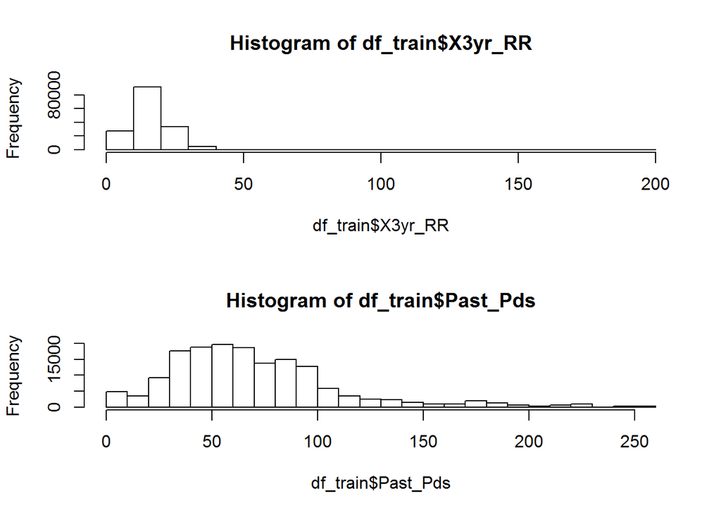

```r
#Histograms showing distributons of continuous features prior to scaling
par(mfrow=c(2,1))
hist(df_train$X3yr_RR)
hist(df_train$Past_Pds)
```

Capping Features for outliers

```r
##cap and flooring for variables replaceoutliers with percentile values (so if above this p99 jus assing value for p99)

df_train$Past_Pds[df_train$Past_Pds > 166] <- 166 ####capping a 95 percentile
df_train$X3yr_RR[df_train$X3yr_RR > 33.0] <- 33.0 ####capping at 99 percentile

df_test$Past_Pds[df_test$Past_Pds > 166] <- 166 ####capping a 95 percentile
df_test$X3yr_RR[df_test$X3yr_RR > 33.0] <- 33.0 ####capping at 99 percentile
```

Contents for un-scaled but capped data

```r
describe(df_train)
```

```
## df_train
##
##  4  Variables      158027  Observations
## ---------------------------------------------------------------------------
## resp_flag
##        n  missing distinct     Info      Sum     Mean      Gmd
##   158027        0        2    0.008      402 0.002544 0.005075
##
## ---------------------------------------------------------------------------
## X3yr_RR
##        n  missing distinct     Info     Mean      Gmd      .05      .10
##   158027        0     1318        1     15.9    6.899    7.750    8.842
##      .25      .50      .75      .90      .95
##   10.944   15.110   19.902   24.632   27.353
##
## lowest :  0.0000  1.7544  1.8182  1.9231  2.3256
## highest: 32.6241 32.6599 32.7303 32.9268 33.0000
## ---------------------------------------------------------------------------
## comp_distance_flag
##        n  missing distinct     Info      Sum     Mean      Gmd
##   158027        0        2    0.637   109730   0.6944   0.4244
##
## ---------------------------------------------------------------------------
## Past_Pds
##        n  missing distinct     Info     Mean      Gmd      .05      .10
##   158027        0      144        1    69.05    40.55       20       29
##      .25      .50      .75      .90      .95
##       43       63       88      119      160
##
## lowest :   0   1   2   3   4, highest: 151 157 159 160 166
## ---------------------------------------------------------------------------
```

```r
describe(df_test)
```

```
## df_test
##
##  4  Variables      158027  Observations
## ---------------------------------------------------------------------------
## resp_flag
##        n  missing distinct     Info      Sum     Mean      Gmd
##   158027        0        2    0.008      402 0.002544 0.005075
##
## ---------------------------------------------------------------------------
## X3yr_RR
##        n  missing distinct     Info     Mean      Gmd      .05      .10
##   158027        0     1318        1     15.9    6.899    7.750    8.842
##      .25      .50      .75      .90      .95
##   10.944   15.110   19.902   24.632   27.353
##
## lowest :  0.0000  1.7544  1.8182  1.9231  2.3256
## highest: 32.6241 32.6599 32.7303 32.9268 33.0000
## ---------------------------------------------------------------------------
## comp_distance_flag
##        n  missing distinct     Info      Sum     Mean      Gmd
##   158027        0        2    0.637   109730   0.6944   0.4244
##
## ---------------------------------------------------------------------------
## Past_Pds
##        n  missing distinct     Info     Mean      Gmd      .05      .10
##   158027        0      144        1    69.05    40.55       20       29
##      .25      .50      .75      .90      .95
##       43       63       88      119      160
##
## lowest :   0   1   2   3   4, highest: 151 157 159 160 166
## ---------------------------------------------------------------------------
```

```r
##Randomly sample march data into train and test datasets
set.seed(7)
##Splits into train and test data from temp table 50/50 (nrows = 79013 each)
df_train <- df_train %>%
  group_by(resp_flag) %>%
  sample_frac(size = 0.5 , replace = F)
df_test <- df_test %>%
  group_by(resp_flag) %>%
  sample_frac(size = 0.5 , replace = F)
```

Scale data - Subtract mean divide by standard deviation

```r
##Pre-processing -- this function applies scale function to features which subtracts mean then divides by standard deviation
df_train[,2] <- sapply(df_train[,2], FUN = "scale")
df_test[,2] <- sapply(df_test[,2], FUN = "scale")

df_train[,4] <- sapply(df_train[,4], FUN = "scale")
df_test[,4]<- sapply(df_test[,4], FUN = "scale")

describe(df_train)
```

```
## df_train
##
##  4  Variables      79013  Observations
## ---------------------------------------------------------------------------
## resp_flag
##        n  missing distinct     Info      Sum     Mean      Gmd
##    79013        0        2    0.008      201 0.002544 0.005075
##
## ---------------------------------------------------------------------------
## X3yr_RR
##         n   missing  distinct      Info      Mean       Gmd       .05
##     79013         0      1317         1 7.336e-17      1.12   -1.3190
##       .10       .25       .50       .75       .90       .95
##   -1.1426   -0.8022   -0.1373    0.6510    1.4262    1.8589
##
## lowest : -2.575353 -2.290941 -2.280598 -2.263593 -2.198342
## highest:  2.713457  2.719260  2.730673  2.762528  2.774395
## ---------------------------------------------------------------------------
## comp_distance_flag
##        n  missing distinct     Info      Sum     Mean      Gmd
##    79013        0        2    0.638    54774   0.6932   0.4253
##
## ---------------------------------------------------------------------------
## Past_Pds
##         n   missing  distinct      Info      Mean       Gmd       .05
##     79013         0       144         1 8.519e-17     1.095   -1.3242
##       .10       .25       .50       .75       .90       .95
##   -1.0815   -0.7039   -0.1645    0.5098    1.3458    2.4516
##
## lowest : -1.863579 -1.836609 -1.809639 -1.782669 -1.755699
## highest:  2.208880  2.370699  2.424639  2.451609  2.613429
## ---------------------------------------------------------------------------
```

```r
describe(df_test)
```

```
## df_test
##
##  4  Variables      79013  Observations
## ---------------------------------------------------------------------------
## resp_flag
##        n  missing distinct     Info      Sum     Mean      Gmd
##    79013        0        2    0.008      201 0.002544 0.005075
##
## ---------------------------------------------------------------------------
## X3yr_RR
##         n   missing  distinct      Info      Mean       Gmd       .05
##     79013         0      1316         1 3.206e-18      1.12   -1.3253
##       .10       .25       .50       .75       .90       .95
##   -1.1452   -0.8056   -0.1253    0.6560    1.4058    1.8622
##
## lowest : -2.588856 -2.302814 -2.292412 -2.275308 -2.209684
## highest:  2.730263  2.736100  2.747578  2.779616  2.791551
## ---------------------------------------------------------------------------
## comp_distance_flag
##        n  missing distinct     Info      Sum     Mean      Gmd
##    79013        0        2    0.638    54769   0.6932   0.4254
##
## ---------------------------------------------------------------------------
## Past_Pds
##          n    missing   distinct       Info       Mean        Gmd
##      79013          0        144          1 -3.405e-17      1.093
##        .05        .10        .25        .50        .75        .90
##    -1.3256    -1.0820    -0.7031    -0.1618     0.5148     1.3539
##        .95
##     2.4636
##
## lowest : -1.866935 -1.839869 -1.812803 -1.785738 -1.758672
## highest:  2.219972  2.382366  2.436497  2.463562  2.625956
## ---------------------------------------------------------------------------
```

Histograms sowing scaled distributions

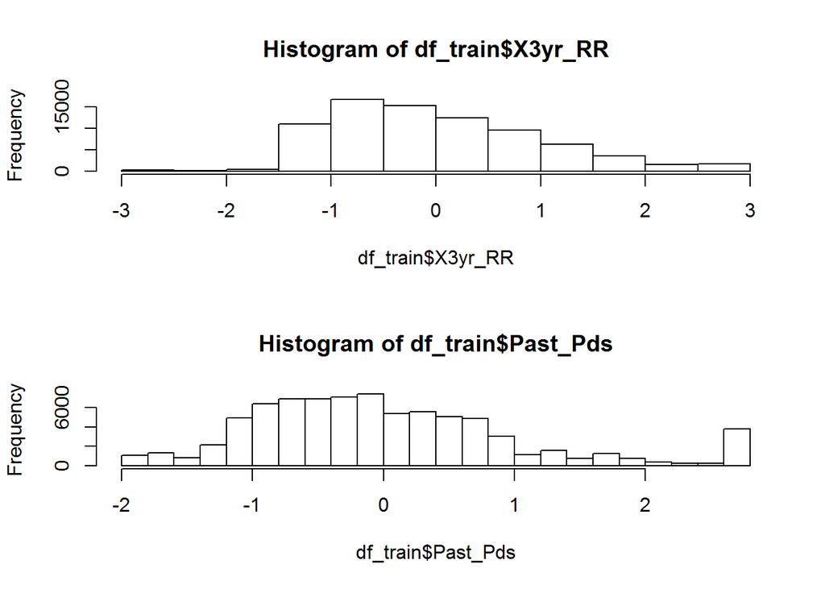

```r
#Histograms showing distributons
par(mfrow=c(2,1))
hist(df_train$X3yr_RR)
hist(df_train$Past_Pds)
```

Coding Dependent Variable

```r
##Sets resp_flag as factor (levels = (0,1)) to avoid issues in logistic regression
#Factor is R's data structure for categorical variables
df_train$resp_flag <- as.factor(df_train$resp_flag)
df_test$resp_flag <- as.factor(df_test$resp_flag)
```

Fitting model

```r
#Model fit
fit <- glm(resp_flag ~ ., family = "binomial", data = df_train)

#Chi-Sq results
wald <- Anova(fit, type = "II", test="Wald")
print(wald)
```

```
## Analysis of Deviance Table (Type II tests)
##
## Response: resp_flag
##                    Df   Chisq Pr(>Chisq)
## X3yr_RR             1 13.6439   0.000221 ***
## comp_distance_flag  1  7.7758   0.005295 **
## Past_Pds            1  3.7095   0.054105 .
## ---
## Signif. codes:  0 '***' 0.001 '**' 0.01 '*' 0.05 '.' 0.1 ' ' 1
```

Summary of model fit

```r
summary(fit)
```

```
##
## Call:
## glm(formula = resp_flag ~ ., family = "binomial", data = df_train)
##
## Deviance Residuals:
##     Min       1Q   Median       3Q      Max
## -0.1287  -0.0800  -0.0679  -0.0556   3.7414
##
## Coefficients:
##                    Estimate Std. Error z value Pr(>|z|)
## (Intercept)        -6.45847    0.16918 -38.175  < 2e-16 ***
## X3yr_RR             0.27832    0.07535   3.694 0.000221 ***
## comp_distance_flag  0.53051    0.19025   2.789 0.005295 **
## Past_Pds            0.14031    0.07285   1.926 0.054105 .
## ---
## Signif. codes:  0 '***' 0.001 '**' 0.01 '*' 0.05 '.' 0.1 ' ' 1
##
## (Dispersion parameter for binomial family taken to be 1)
##
##     Null deviance: 2803.1  on 79012  degrees of freedom
## Residual deviance: 2756.1  on 79009  degrees of freedom
## AIC: 2764.1
##
## Number of Fisher Scoring iterations: 9
```

Train Model and store predictions as column in test set

```r
df_train$resp_flag <- as.factor(df_train$resp_flag)
model <- train(resp_flag ~ ., method = "glm", family = "binomial", data = df_train)

##Storing preds
predicts <- predict(model, type = "prob", newdata = df_test)
df_test$preds <- predicts$`1`

head(df_test, 50)
```

```
## # A tibble: 50 x 5
## # Groups:   resp_flag [1]
##    resp_flag X3yr_RR comp_distance_flag Past_Pds   preds
##    <fct>       <dbl>              <int>    <dbl>   <dbl>
##  1 0           0.370                  1   -0.189 0.00287
##  2 0           0.416                  1   -0.189 0.00290
##  3 0          -0.777                  1    0.109 0.00217
##  4 0          -1.16                   1    0.325 0.00201
##  5 0          -0.111                  1    0.163 0.00264
##  6 0          -1.25                   1   -0.893 0.00166
##  7 0           1.41                   1   -0.162 0.00384
##  8 0          -0.579                  1   -0.405 0.00214
##  9 0          -1.40                   1    0.623 0.00197
## 10 0           0.813                  1    1.95  0.00437
## # ... with 40 more rows
```

Aggregate both actual and predicted resposnes to decile level

```r
##Creating decile column on test set based on predictions column
df_test$decile <-with(df_test, cut(preds,
                                breaks=quantile(preds, probs=seq(0,1, by=0.1)), labels = c(1:10),
                                include.lowest=TRUE))

###Reporting response rate predictions per decile vs. actual response rates
df_decile_info <- df_test %>%
  group_by(decile) %>%
  summarise(pred_resp = mean(preds),
            actual_resp = mean(as.numeric(resp_flag)-1))

##drop these output vars to run again
#df_test <- df_test[,-which(names(df_test) %in% c("decile", "preds"))]





head(df_decile_info,10)
```

```
## # A tibble: 10 x 3
##    decile pred_resp actual_resp
##    <fct>      <dbl>       <dbl>
##  1 1        0.00101     0.00101
##  2 2        0.00122     0.00215
##  3 3        0.00155     0.00138
##  4 4        0.00188     0.00241
##  5 5        0.00218     0.00190
##  6 6        0.00247     0.00241
##  7 7        0.00280     0.00278
##  8 8        0.00322     0.00330
##  9 9        0.00385     0.00366
## 10 10       0.00527     0.00444
```

Error Report

```r
df_decile_info <- df_decile_info %>%
  mutate(error = abs(pred_resp - actual_resp))


avg_error <- mean(df_decile_info$error)
```

The average error for fitted vs predicted value is **0.0003110** or **0.03 percent**.

Contents of data after predictions appended

```r
describe(df_test)
```

```
## df_test
##
##  6  Variables      79013  Observations
## ---------------------------------------------------------------------------
## resp_flag
##        n  missing distinct
##    79013        0        2
##
## Value          0     1
## Frequency  78812   201
## Proportion 0.997 0.003
## ---------------------------------------------------------------------------
## X3yr_RR
##         n   missing  distinct      Info      Mean       Gmd       .05
##     79013         0      1316         1 3.206e-18      1.12   -1.3253
##       .10       .25       .50       .75       .90       .95
##   -1.1452   -0.8056   -0.1253    0.6560    1.4058    1.8622
##
## lowest : -2.588856 -2.302814 -2.292412 -2.275308 -2.209684
## highest:  2.730263  2.736100  2.747578  2.779616  2.791551
## ---------------------------------------------------------------------------
## comp_distance_flag
##        n  missing distinct     Info      Sum     Mean      Gmd
##    79013        0        2    0.638    54769   0.6932   0.4254
##
## ---------------------------------------------------------------------------
## Past_Pds
##          n    missing   distinct       Info       Mean        Gmd
##      79013          0        144          1 -3.405e-17      1.093
##        .05        .10        .25        .50        .75        .90
##    -1.3256    -1.0820    -0.7031    -0.1618     0.5148     1.3539
##        .95
##     2.4636
##
## lowest : -1.866935 -1.839869 -1.812803 -1.785738 -1.758672
## highest:  2.219972  2.382366  2.436497  2.463562  2.625956
## ---------------------------------------------------------------------------
## preds
##        n  missing distinct     Info     Mean      Gmd      .05      .10
##    79013        0     1581        1 0.002545 0.001382 0.001027 0.001104
##      .25      .50      .75      .90      .95
## 0.001558 0.002310 0.003203 0.004372 0.005104
##
## lowest : 0.0005863894 0.0005886191 0.0007069194 0.0007142073 0.0007233617
## highest: 0.0074736457 0.0075583547 0.0078807510 0.0081786927 0.0083048371
## ---------------------------------------------------------------------------
## decile
##        n  missing distinct
##    79013        0       10
##
## Value          1     2     3     4     5     6     7     8     9    10
## Frequency   7909  7904  7944  7883  7881  7889  7911  7889  7923  7880
## Proportion 0.100 0.100 0.101 0.100 0.100 0.100 0.100 0.100 0.100 0.100
## ---------------------------------------------------------------------------
```

Predicted vs. Actual graphs

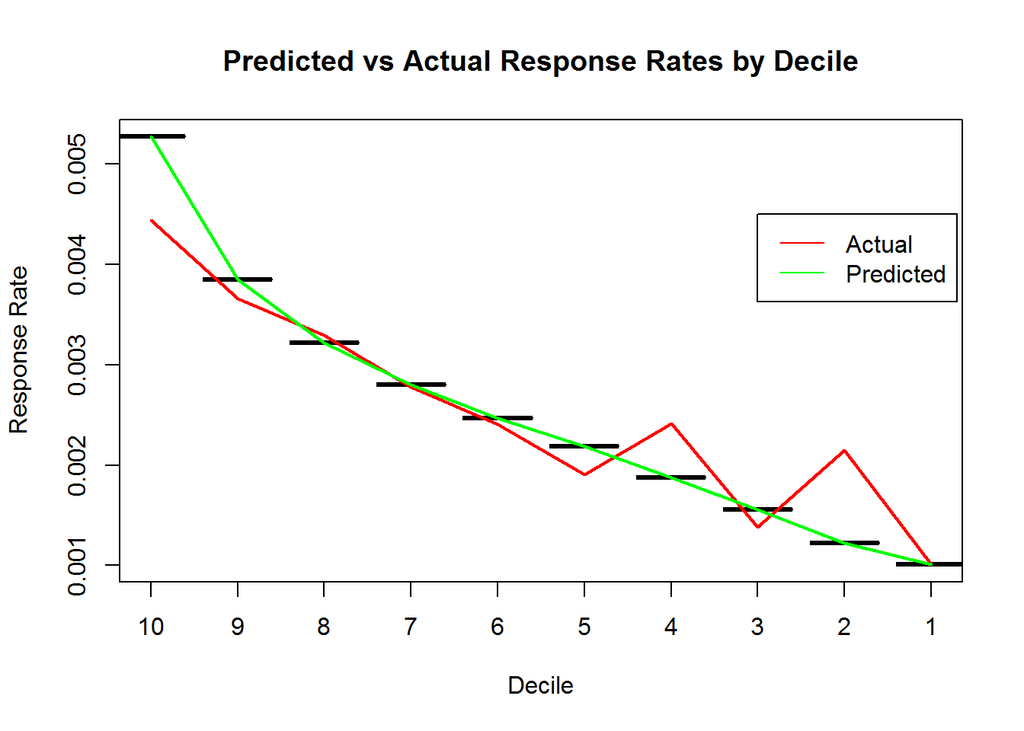

```r
plot(df_decile_info$decile,df_decile_info$pred_resp,col="red", xlim = c(10,1), xlab = "Decile", ylab = "Response Rate", main = "Predicted vs Actual Response Rates by Decile")
lines(df_decile_info$decile,df_decile_info$actual_resp, col="red", lwd = 2)
lines(df_decile_info$decile,df_decile_info$pred_resp, col="green", lwd = 2)
legend(3, 0.0045, legend=c("Actual", "Predicted"),
       col=c("red", "green"), lty=1)
```

ROC Curve

```r
##ROC Curve Evaluation
roc_obj <- roc(df_test$resp_flag , df_test$preds)
auc(roc_obj)
```

```
## Area under the curve: 0.6078
```

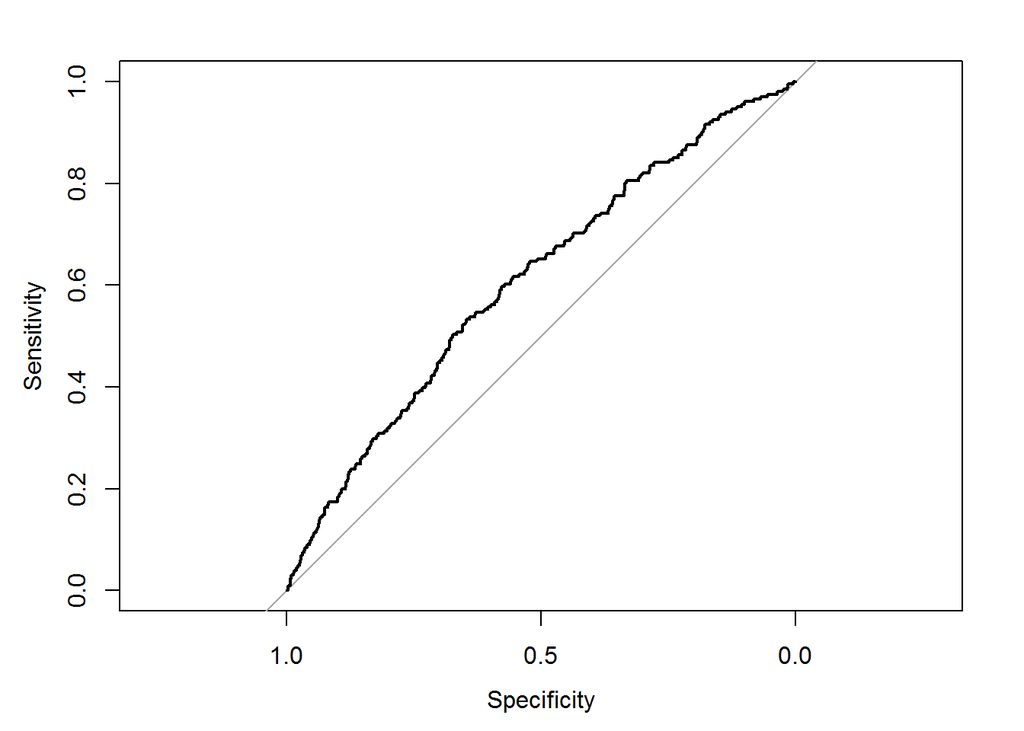

```r
plot(roc_obj)
```

Below is the logistic equation for predicting probability of response at the household level using 3yr_RR (response rate), comp_distance_flag, and Past_Pds (Past Paids).Response Rate and Past Paids are standardized by subtracting the mean and dividing by the standard deviation. Response rates and past paids are capped at 99th and 95th percentiles respectively. Filtered for no name records only, SOURCE = MW0, and BJsClub1 not in ( 038, 045, 048, 061, 062, 067, 093, 123, 129, 139, 141, 150, 168, 180, 184, 185, 189, 211, 318, 370 )

Linear Equation: = $-6.45847 + 0.27832X_{x3yr.RR} + 0.53051X_{comp.distance.flag} + 0.14031X_{Past.Pds}$

Logistic Equation for predicting Probability: (after capped outliers) $P(resp.flag = 1) = \frac{e^{-6.45847 + 0.27832X_{x3yr.RR} + 0.53051X_{comp.distance.flag} + 0.14031X_{Past.Pds}}}{1 + e^{-6.45847 + 0.27832X_{x3yr.RR} + 0.53051X_{comp.distance.flag} + 0.14031X_{Past.Pds}}}$

(prior to capped outliers) $P(resp.flag = 1) = \frac{e^{-6.1031288 + 0.2377197X_{x3yr.RR} + 0.2581363X_{comp.distance.flag} + 0.1965876X_{Past.Pds}}}{1 + e^{-6.1031288 + 0.2377197X_{x3yr.RR} + 0.2581363X_{comp.distance.flag} + 0.1965876X_{Past.Pds}}}$